# HW 09: Python

Yashvi Malviya

2023-11-18

© 2023 David Gerard, not to be posted online, or uploaded to an AI.

# Instructions

- Write your solutions in this starter file. You should modify the “author” field in the YAML header.
- Only commit R Markdown and HTML files (no PDF files). Make sure you have knitted to HTML for your final submission.
- **Make sure to commit each time you answer a question.**
- Only include the necessary code, not any extraneous code, to answer the questions.
- Use only Python code (no R code).
- Use only Python functions from numpy, pandas, and seaborn (and functions that come with base Python).
- Do not change the path of any files.
- Learning objectives:
  - Numpy, Pandas, Seaborn

# World Bank Data

The World Bank is an international organization that provides loans to countries with the goal of reducing poverty. The data frames in the dt folder were all taken from the public data repositories of the World Bank.

- country.csv: Contains information on the countries in the data set. The variables are:
  - `Country_Code`: A three-letter code for the country. Note that not all rows are countries; some are regions.
  - `Region`: The region of the country.
  - `IncomeGroup`: Either `"High income"`, `"Upper middle income"`, `"Lower middle income"`, or `"Low income"`.
  - `TableName`: The full name of the country.
- fertility.csv: Contains the fertility rate information for each country for each year. For the variables `1960` to `2017`, the values in the cells represent the fertility rate in total births per woman for the that year. Total fertility rate represents the number of children that would be born to a woman if she were to live to the end of her childbearing years and bear children in accordance with age-specific fertility rates of the specified year.
- life_exp.csv: Contains the life expectancy information for each country for each year. For the variables `1960` to `2017`, the values in the cells represent life expectancy at birth in years for the given year. Life expectancy at birth indicates the number of years a newborn infant would live if prevailing patterns of mortality at the time of its birth were to stay the same throughout its life.
- population.csv: Contains the population information for each country. For the variables `1960` to `2017`, the values in the cells represent the total population in number of people for the given year. Total population is based on the de facto definition of population, which counts all residents regardless of legal status or citizenship. The values shown are midyear estimates.
1. (1 pt) Use relative paths to load these data frames into Python.

```python
destination_directory = r"C:\Users\nishi\OneDrive\Desktop\data_613\hw-09-python-Ym7137a\analysis"
current_directory = os.getcwd()
print("Current Working Directory:", current_directory)
```

```
## Current Working Directory: C:\Users\nishi\OneDrive\Desktop\data_613\hw-09-python-Ym7137a\analysis
```

```python
os.chdir(destination_directory)
new_current_directory = os.getcwd()
print("New Current Working Directory:", new_current_directory)
```

```
## New Current Working Directory: C:\Users\nishi\OneDrive\Desktop\data_613\hw-09-python-Ym7137a\analysis
```

```python
import pandas as pd

dt_folder_path = os.path.join(destination_directory, '..', 'dt')

files = ['country.csv', 'fertility.csv', 'life_exp.csv', 'population.csv']

file_paths = [os.path.join(dt_folder_path, file) for file in files]

country, fert, life, pop = [pd.read_csv(file_path) for file_path in file_paths]


print("Country Data:")
```

```
## Country Data:
```

```python
print(country.head())
```

```
##   Country Code                     Region          IncomeGroup    TableName
## 0          ABW  Latin America & Caribbean          High income        Aruba
## 1          AFG                 South Asia           Low income  Afghanistan
## 2          AGO         Sub-Saharan Africa  Lower middle income       Angola
## 3          ALB      Europe & Central Asia  Upper middle income      Albania
## 4          AND      Europe & Central Asia          High income      Andorra
```

2. (2 pts) These data are messy. The observational units in `fert`, `life`, and `pop` are locations in space-time (e.g. Aruba in 2017). Recall that tidy data should have one observational unit per row. Make these data tidy now.

```python
def make_tidy(df, var_name):
    df_tidy = pd.melt(
        df,
        id_vars=['Country Name', 'Country Code'],
        var_name='Year',
        value_name=var_name
    )
    return df_tidy


pop_tidy = make_tidy(pop, 'Population')

print(pop_tidy.head())
```

```
##   Country Name Country Code  Year  Population
## 0        Aruba          ABW  1960     54211.0
## 1  Afghanistan          AFG  1960   8996351.0
## 2       Angola          AGO  1960   5643182.0
## 3      Albania          ALB  1960   1608800.0
## 4      Andorra          AND  1960     13411.0
```

```python
life_tidy = make_tidy(life, 'Life Expectancy')

print(life_tidy.head())
```

```
##   Country Name Country Code  Year  Life Expectancy
## 0        Aruba          ABW  1960           65.662
## 1  Afghanistan          AFG  1960           32.292
## 2       Angola          AGO  1960           33.251
## 3      Albania          ALB  1960           62.279
## 4      Andorra          AND  1960              NaN
```

```python
fert_tidy = make_tidy(fert, 'Fertility')

print(fert_tidy)
```

```
##        Country Name Country Code  Year  Fertility
## 0             Aruba          ABW  1960      4.820
## 1       Afghanistan          AFG  1960      7.450
## 2            Angola          AGO  1960      7.478
## 3           Albania          ALB  1960      6.489
## 4           Andorra          AND  1960        NaN
## ...             ...          ...   ...        ...
## 15571        Kosovo          XKX  2018        NaN
## 15572   Yemen, Rep.          YEM  2018        NaN
## 15573  South Africa          ZAF  2018        NaN
## 15574        Zambia          ZMB  2018        NaN
## 15575      Zimbabwe          ZWE  2018        NaN
##
## [15576 rows x 4 columns]
```

```python
import pandas as pd
import numpy as np


merged_df = fert_tidy.merge(life_tidy, how='outer', on=['Country Name', 'Country Code', 'Year'])
merged_df = merged_df.merge(pop_tidy, how='outer', on=['Country Name', 'Country Code', 'Year'])


wb_df = merged_df.merge(country, how='left', left_on='Country Code', right_on='Country Code')


wb_df = wb_df.rename(columns={'Fertility': 'fert_rate', 'Life Expectancy': 'life_exp', 'Population': 'population'})


wb_df = wb_df[['Country Name', 'Country Code', 'Year', 'fert_rate', 'life_exp', 'population', 'Region']]

wb_df.head()
```

```
##   Country Name Country Code  ... population                     Region
## 0        Aruba          ABW  ...    54211.0  Latin America & Caribbean
## 1  Afghanistan          AFG  ...  8996351.0                 South Asia
## 2       Angola          AGO  ...  5643182.0         Sub-Saharan Africa
## 3      Albania          ALB  ...  1608800.0      Europe & Central Asia
## 4      Andorra          AND  ...    13411.0      Europe & Central Asia
##
## [5 rows x 7 columns]
```

```python
wb_df.info()
```

```
## <class 'pandas.core.frame.DataFrame'>
## RangeIndex: 15576 entries, 0 to 15575
## Data columns (total 7 columns):
##  #   Column        Non-Null Count  Dtype
## ---  ------        --------------  -----
##  0   Country Name  15576 non-null  object
##  1   Country Code  15576 non-null  object
##  2   Year          15576 non-null  object
##  3   fert_rate     14016 non-null  float64
##  4   life_exp      13997 non-null  float64
##  5   population    15147 non-null  float64
##  6   Region        12803 non-null  object
## dtypes: float64(3), object(4)
## memory usage: 851.9+ KB
```

4. (2 pts) Make a scatterplot of fertility rate vs life expectancy, color-coding by region. Do this for the years 1960, 1970, 1980, 1990, 2000, and 2010. Facet by these years. Make your plot aesthetically pleasing. Your final plot should look like this:

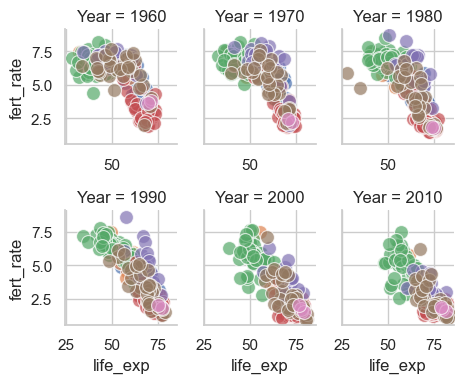

```python
import seaborn as sns
import matplotlib.pyplot as plt

selected_years = ['1960', '1970', '1980', '1990', '2000', '2010']
filtered_data = wb_df[wb_df['Year'].isin(selected_years)]
sns.set(style="whitegrid")
g= sns.FacetGrid(filtered_data, col="Year", hue="Region", col_wrap=3, height=2, aspect=0.80)
g.map(sns.scatterplot, "life_exp", "fert_rate", alpha=0.7, edgecolor="w", s=100)
```

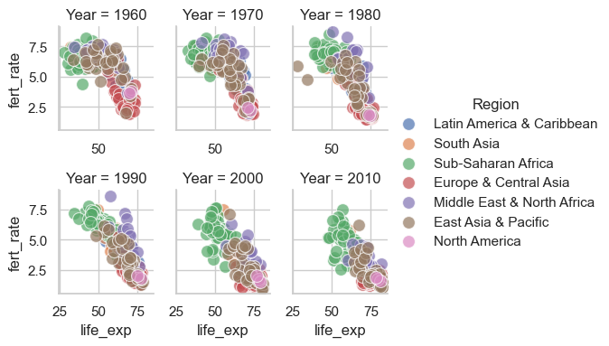

```python
g.add_legend()
```

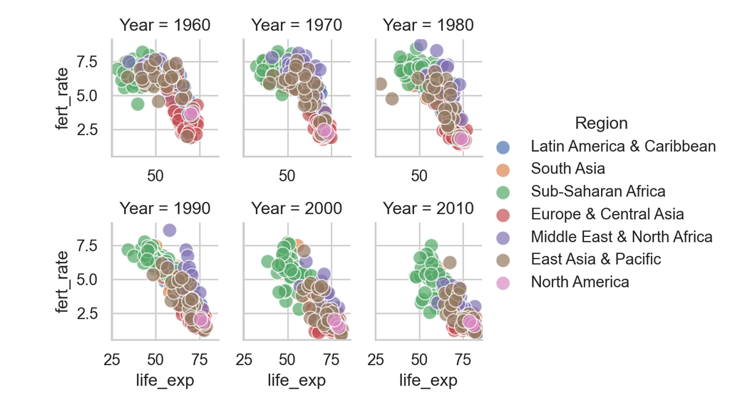

```python
plt.show()
```

5. (2 pts) Calculate the total population for each region for each year. Exclude 2018. Make a line plot of year versus total population, color-coding by region. Your final plot should look like this:

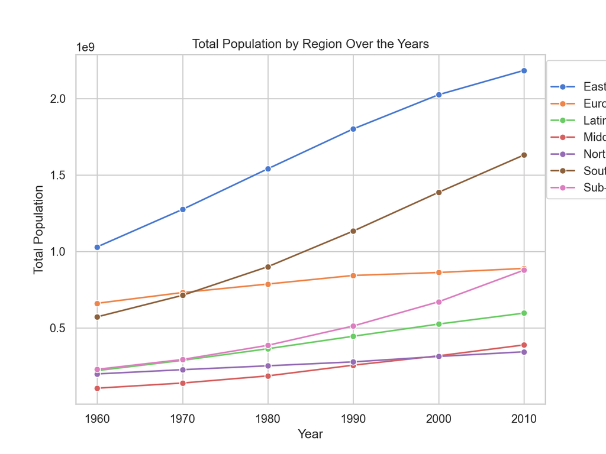

```python
import matplotlib.pyplot as plt
import seaborn as sns

selected_years = ['1960', '1970', '1980', '1990', '2000', '2010']
filtered_data = wb_df[wb_df['Year'].isin(selected_years)]

total_population = filtered_data.groupby(['Year', 'Region'])['population'].sum().reset_index()


sns.set(style="whitegrid")
plt.figure(figsize=(8, 6))
sns.lineplot(x='Year', y='population', hue='Region', data=total_population, marker='o', palette='muted')

plt.xlabel('Year')
plt.ylabel('Total Population')
plt.title('Total Population by Region Over the Years')


plt.legend(title='Region', bbox_to_anchor=(0.99, 1), loc='upper left')

plt.show()
```

6. (2 pts) Make a bar plot of population vs region for the year 2017. Your final plot should look like this:

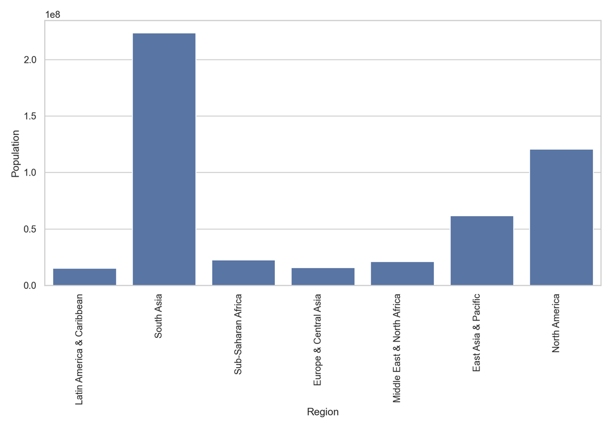

```python
import matplotlib.pyplot as plt
import seaborn as sns


data_2017 = wb_df[wb_df['Year'] == '2017']

fig, ax = plt.subplots(figsize=(10, 7))

sns.set(style="whitegrid")
sns.barplot(x='Region', y='population', data=data_2017, ci=None, ax=ax)

ax.set_xlabel('Region')
ax.set_ylabel('Population')


ax.set_xticklabels(ax.get_xticklabels(), rotation=90, ha='right')
plt.tight_layout()
plt.show()
```